# Machine Learning Assignment: Prediction Assignment Writeup

Chetan Rao

February 27, 2016

## Prediction Assignment Writeup Introduction

Assignment Background Information: Use data from accelerometers on the belt, forearm, arm, and dumbell of 6 participants. They were asked to perform barbell lifts correctly and incorrectly in 5 different ways. More information is available from the website here: http://groupware.les.inf.puc-rio.br/har (see the section on the Weight Lifting Exercise Dataset).

The training data for this project are available here: https://d396qusza40orc.cloudfront.net/predmachlearn/pml-training.csv

The test data are available here: https://d396qusza40orc.cloudfront.net/predmachlearn/pml-testing.csv

GOAL: Predict the manner in which they did the exercise. This is the “classe” variable in the training set. You may use any of the other variables to predict with. Link to a Github repo with your R markdown and compiled HTML file describing your analysis. How you built your model, how you used cross validation, what you think the expected out of sample error is, and why you made the choices you did. You will also use your prediction model to predict 20 different test cases.

SOURCE: All the data here is referenced from: http://groupware.les.inf.puc-rio.br/har

### Load Training and Testing Dataset

```r
trainUrl<-'https://d396qusza40orc.cloudfront.net/predmachlearn/pml-training.csv'
testUrl<-'https://d396qusza40orc.cloudfront.net/predmachlearn/pml-testing.csv'
trainData <- read.csv(url(trainUrl), header=TRUE, sep=",")
testData <- read.csv(url(testUrl), header=TRUE, sep=",")
#trainData <- read.csv(file="C:\\coursera\\machineLearning\\data\\pml-training.csv", header=TRUE, sep=",")
#testData <- read.csv(file="C:\\coursera\\machineLearning\\data\\pml-testing.csv", header=TRUE, sep=",")
```

### Training And Validation Data Sets using Caret

```r
set.seed(1234)
#Now use the principal Components to  as the predictor variables to train the model.
inTrain<-createDataPartition(trainData$classe,p=3/4,list=FALSE)
trainingSubset<-prinComponents[inTrain,]
validationSet<-prinComponents[-inTrain,]
inTrain<-createDataPartition(validationSet$classe,p=3/4,list=FALSE)
ValidationSetForTest <- validationSet[-inTrain,]
validationSet <- validationSet[inTrain,]
```

### Cross Validating using the ValidationDataSet and Calculating the Confusion Matrix.

```r
predict1_gbm <- predict(model1,validationSet)
predict2_pls <- predict(model2,validationSet)
predict3_lda <- predict(model3,validationSet)
predict4_rf <- predict(model4,validationSet)
confusionMatrix(predict1_gbm,validationSet$classe)
```

```
## Confusion Matrix and Statistics
##
##           Reference
## Prediction   A   B   C   D   E
##          A 891  88  76  41  47
##          B  34 495  55  27  43
##          C  56  62 465  63  64
##          D  58  40  29 454  38
##          E   8  27  17  18 484
##
## Overall Statistics
##
##                Accuracy : 0.7579
##                  95% CI : (0.7437, 0.7716)
##     No Information Rate : 0.2845
##     P-Value [Acc > NIR] : < 2.2e-16
##
##                   Kappa : 0.6929
##  Mcnemar's Test P-Value : < 2.2e-16
##
## Statistics by Class:
##
##                      Class: A Class: B Class: C Class: D Class: E
## Sensitivity            0.8510   0.6952   0.7243   0.7529   0.7160
## Specificity            0.9043   0.9464   0.9194   0.9464   0.9767
## Pos Pred Value         0.7795   0.7569   0.6549   0.7334   0.8736
## Neg Pred Value         0.9385   0.9283   0.9404   0.9513   0.9386
## Prevalence             0.2845   0.1935   0.1745   0.1639   0.1837
## Detection Rate         0.2421   0.1345   0.1264   0.1234   0.1315
## Detection Prevalence   0.3106   0.1777   0.1929   0.1682   0.1505
## Balanced Accuracy      0.8776   0.8208   0.8218   0.8496   0.8463
```

```r
confusionMatrix(predict2_pls,validationSet$classe)
```

```
## Confusion Matrix and Statistics
##
##           Reference
## Prediction   A   B   C   D   E
##          A 784 311 430 131 223
##          B  52 193  36 106 160
##          C  43  38  80  64  87
##          D 126 128  87 242 162
##          E  42  42   9  60  44
##
## Overall Statistics
##
##                Accuracy : 0.3649
##                  95% CI : (0.3494, 0.3807)
##     No Information Rate : 0.2845
##     P-Value [Acc > NIR] : < 2.2e-16
##
##                   Kappa : 0.1733
##  Mcnemar's Test P-Value : < 2.2e-16
##
## Statistics by Class:
##
##                      Class: A Class: B Class: C Class: D Class: E
## Sensitivity            0.7488  0.27107  0.12461  0.40133  0.06509
## Specificity            0.5841  0.88073  0.92363  0.83653  0.94907
## Pos Pred Value         0.4172  0.35283  0.25641  0.32483  0.22335
## Neg Pred Value         0.8540  0.83434  0.83314  0.87700  0.81855
## Prevalence             0.2845  0.19348  0.17446  0.16386  0.18370
## Detection Rate         0.2130  0.05245  0.02174  0.06576  0.01196
## Detection Prevalence   0.5106  0.14864  0.08478  0.20245  0.05353
## Balanced Accuracy      0.6665  0.57590  0.52412  0.61893  0.50708
```

```r
confusionMatrix(predict3_lda,validationSet$classe)
```

```
## Confusion Matrix and Statistics
##
##           Reference
## Prediction   A   B   C   D   E
##          A 708 170 288  63 112
##          B  57 258  53 138 123
##          C  86  95 199  84  95
##          D 138 103  56 256  81
##          E  58  86  46  62 265
##
## Overall Statistics
##
##                Accuracy : 0.4582
##                  95% CI : (0.442, 0.4744)
##     No Information Rate : 0.2845
##     P-Value [Acc > NIR] : < 2.2e-16
##
##                   Kappa : 0.3077
##  Mcnemar's Test P-Value : < 2.2e-16
##
## Statistics by Class:
##
##                      Class: A Class: B Class: C Class: D Class: E
## Sensitivity            0.6762  0.36236  0.30997  0.42454  0.39201
## Specificity            0.7596  0.87500  0.88150  0.87715  0.91611
## Pos Pred Value         0.5280  0.41017  0.35599  0.40379  0.51257
## Neg Pred Value         0.8551  0.85120  0.85806  0.88608  0.87006
## Prevalence             0.2845  0.19348  0.17446  0.16386  0.18370
## Detection Rate         0.1924  0.07011  0.05408  0.06957  0.07201
## Detection Prevalence   0.3644  0.17092  0.15190  0.17228  0.14049
## Balanced Accuracy      0.7179  0.61868  0.59573  0.65085  0.65406
```

```r
confusionMatrix(predict4_rf,validationSet$classe)
```

```
## Confusion Matrix and Statistics
##
##           Reference
## Prediction    A    B    C    D    E
##          A 1030   12    6    0    3
##          B    3  680   12    2    3
##          C   12   12  610   24    4
##          D    1    7   10  573    9
##          E    1    1    4    4  657
##
## Overall Statistics
##
##                Accuracy : 0.9647
##                  95% CI : (0.9582, 0.9704)
##     No Information Rate : 0.2845
##     P-Value [Acc > NIR] : < 2e-16
##
##                   Kappa : 0.9553
##  Mcnemar's Test P-Value : 0.02205
##
## Statistics by Class:
##
##                      Class: A Class: B Class: C Class: D Class: E
## Sensitivity            0.9838   0.9551   0.9502   0.9502   0.9719
## Specificity            0.9920   0.9933   0.9829   0.9912   0.9967
## Pos Pred Value         0.9800   0.9714   0.9215   0.9550   0.9850
## Neg Pred Value         0.9935   0.9893   0.9894   0.9903   0.9937
## Prevalence             0.2845   0.1935   0.1745   0.1639   0.1837
## Detection Rate         0.2799   0.1848   0.1658   0.1557   0.1785
## Detection Prevalence   0.2856   0.1902   0.1799   0.1630   0.1812
## Balanced Accuracy      0.9879   0.9742   0.9665   0.9707   0.9843
```

### out-of-sample Error

```r
#Find the best fit based of Cross Validation
predict1_gbm <- predict(model1,ValidationSetForTest)
predict2_pls <- predict(model2,ValidationSetForTest)
predict3_lda <- predict(model3,ValidationSetForTest)
predict4_rf <- predict(model4,ValidationSetForTest)
confusionMatrix(predict1_gbm,ValidationSetForTest$classe)
```

```
## Confusion Matrix and Statistics
##
##           Reference
## Prediction   A   B   C   D   E
##          A 285  33  31  12  19
##          B  19 152  12   9  17
##          C  16  27 158  24  16
##          D  25  12   7 150   7
##          E   3  13   5   6 166
##
## Overall Statistics
##
##                Accuracy : 0.7443
##                  95% CI : (0.7189, 0.7685)
##     No Information Rate : 0.2843
##     P-Value [Acc > NIR] : < 2.2e-16
##
##                   Kappa : 0.6757
##  Mcnemar's Test P-Value : 1.092e-06
##
## Statistics by Class:
##
##                      Class: A Class: B Class: C Class: D Class: E
## Sensitivity            0.8190   0.6414   0.7418   0.7463   0.7378
## Specificity            0.8916   0.9422   0.9179   0.9501   0.9730
## Pos Pred Value         0.7500   0.7273   0.6556   0.7463   0.8601
## Neg Pred Value         0.9254   0.9163   0.9440   0.9501   0.9428
## Prevalence             0.2843   0.1936   0.1740   0.1642   0.1838
## Detection Rate         0.2328   0.1242   0.1291   0.1225   0.1356
## Detection Prevalence   0.3105   0.1708   0.1969   0.1642   0.1577
## Balanced Accuracy      0.8553   0.7918   0.8298   0.8482   0.8554
```

```r
confusionMatrix(predict2_pls,ValidationSetForTest$classe)
```

```
## Confusion Matrix and Statistics
##
##           Reference
## Prediction   A   B   C   D   E
##          A 271 105 138  40  78
##          B   9  55  11  34  59
##          C  16  22  27  15  15
##          D  44  42  32  84  50
##          E   8  13   5  28  23
##
## Overall Statistics
##
##                Accuracy : 0.3758
##                  95% CI : (0.3486, 0.4036)
##     No Information Rate : 0.2843
##     P-Value [Acc > NIR] : 3.024e-12
##
##                   Kappa : 0.187
##  Mcnemar's Test P-Value : < 2.2e-16
##
## Statistics by Class:
##
##                      Class: A Class: B Class: C Class: D Class: E
## Sensitivity            0.7787  0.23207  0.12676  0.41791  0.10222
## Specificity            0.5879  0.88551  0.93274  0.83578  0.94595
## Pos Pred Value         0.4288  0.32738  0.28421  0.33333  0.29870
## Neg Pred Value         0.8699  0.82765  0.83525  0.87963  0.82389
## Prevalence             0.2843  0.19363  0.17402  0.16422  0.18382
## Detection Rate         0.2214  0.04493  0.02206  0.06863  0.01879
## Detection Prevalence   0.5163  0.13725  0.07761  0.20588  0.06291
## Balanced Accuracy      0.6833  0.55879  0.52975  0.62684  0.52408
```

```r
confusionMatrix(predict3_lda,ValidationSetForTest$classe)
```

```
## Confusion Matrix and Statistics
##
##           Reference
## Prediction   A   B   C   D   E
##          A 245  57  89  19  33
##          B  14  80  19  46  39
##          C  24  41  67  17  36
##          D  48  32  23  99  10
##          E  17  27  15  20 107
##
## Overall Statistics
##
##                Accuracy : 0.4886
##                  95% CI : (0.4602, 0.517)
##     No Information Rate : 0.2843
##     P-Value [Acc > NIR] : < 2.2e-16
##
##                   Kappa : 0.3469
##  Mcnemar's Test P-Value : < 2.2e-16
##
## Statistics by Class:
##
##                      Class: A Class: B Class: C Class: D Class: E
## Sensitivity            0.7040  0.33755  0.31455  0.49254  0.47556
## Specificity            0.7740  0.88045  0.88328  0.88954  0.92092
## Pos Pred Value         0.5530  0.40404  0.36216  0.46698  0.57527
## Neg Pred Value         0.8681  0.84698  0.85948  0.89921  0.88632
## Prevalence             0.2843  0.19363  0.17402  0.16422  0.18382
## Detection Rate         0.2002  0.06536  0.05474  0.08088  0.08742
## Detection Prevalence   0.3619  0.16176  0.15114  0.17320  0.15196
## Balanced Accuracy      0.7390  0.60900  0.59892  0.69104  0.69824
```

```r
confusionMatrix(predict4_rf,ValidationSetForTest$classe)
```

```
## Confusion Matrix and Statistics
##
##           Reference
## Prediction   A   B   C   D   E
##          A 337   8   3   1   0
##          B   4 223   5   0   1
##          C   1   6 201  11   1
##          D   5   0   3 189   1
##          E   1   0   1   0 222
##
## Overall Statistics
##
##                Accuracy : 0.9575
##                  95% CI : (0.9447, 0.9681)
##     No Information Rate : 0.2843
##     P-Value [Acc > NIR] : < 2.2e-16
##
##                   Kappa : 0.9463
##  Mcnemar's Test P-Value : NA
##
## Statistics by Class:
##
##                      Class: A Class: B Class: C Class: D Class: E
## Sensitivity            0.9684   0.9409   0.9437   0.9403   0.9867
## Specificity            0.9863   0.9899   0.9812   0.9912   0.9980
## Pos Pred Value         0.9656   0.9571   0.9136   0.9545   0.9911
## Neg Pred Value         0.9874   0.9859   0.9880   0.9883   0.9970
## Prevalence             0.2843   0.1936   0.1740   0.1642   0.1838
## Detection Rate         0.2753   0.1822   0.1642   0.1544   0.1814
## Detection Prevalence   0.2851   0.1904   0.1797   0.1618   0.1830
## Balanced Accuracy      0.9773   0.9654   0.9624   0.9658   0.9923
```

```r
trueClass<-ValidationSetForTest$classe
# Visually we could check the below results and see some differences. Which is also provided by confusionMatrix.
df<-cbind(predict1_gbm,predict2_pls,predict3_lda,predict4_rf,trueClass)
tail(df)
```

```
##         predict1_gbm predict2_pls predict3_lda predict4_rf trueClass
## [1219,]            2            1            1           5         5
## [1220,]            5            1            5           5         5
## [1221,]            5            2            5           5         5
## [1222,]            5            4            5           5         5
## [1223,]            5            4            5           5         5
## [1224,]            5            2            5           5         5
```

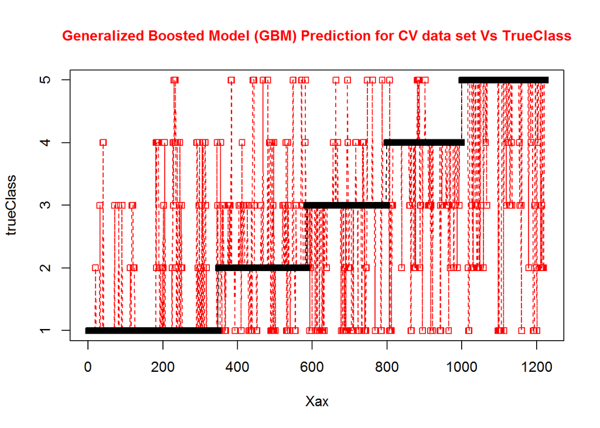

```r
Xax<-1:length(trueClass)

plot(Xax,trueClass,col='white')
lines(predict1_gbm, type="o", pch=22, lty=2, col="red")
lines(trueClass, type="o", pch=22, lty=2, col="black")
title(main="Generalized Boosted Model (GBM) Prediction for CV data set Vs TrueClass",cex.main=1, col.main="red", font.main=2)
```

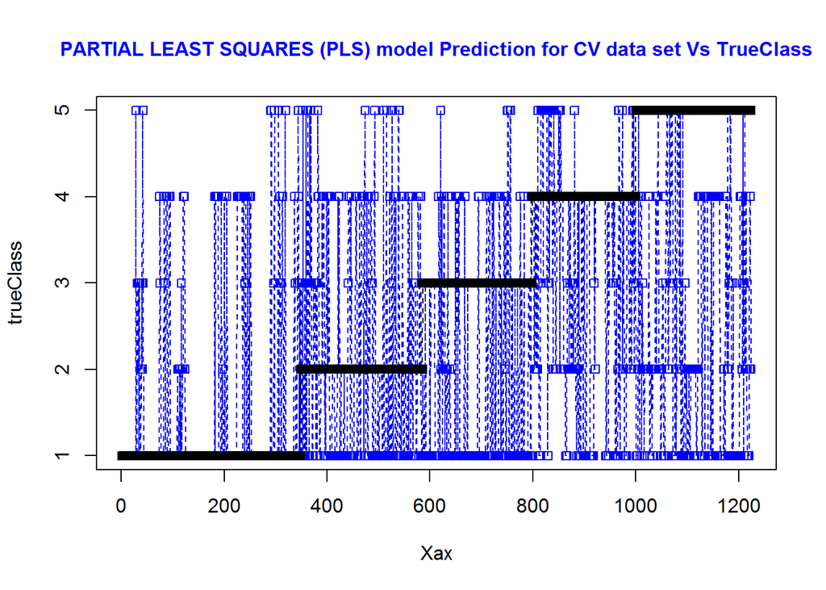

```r
plot(Xax,trueClass,col='white')
lines(predict2_pls, type="o", pch=22, lty=2, col="blue")
lines(trueClass, type="o", pch=22, lty=2, col="black")
title(main="PARTIAL LEAST SQUARES (PLS) model Prediction for CV data set Vs TrueClass",cex.main=1, col.main="blue", font.main=2)
```

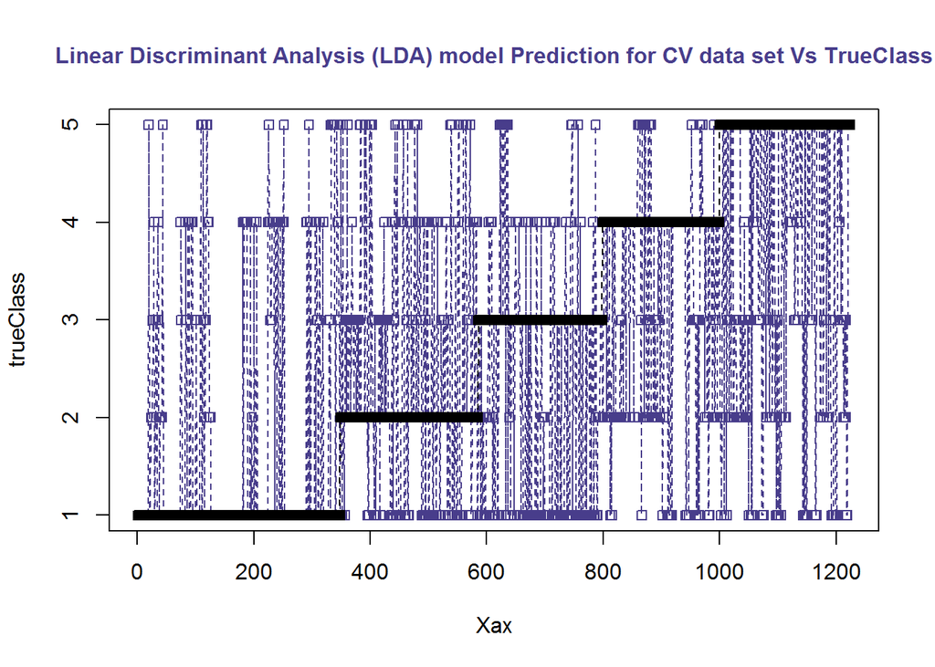

```r
plot(Xax,trueClass,col='white')
lines(predict3_lda, type="o", pch=22, lty=2, col="darkslateblue")
lines(trueClass, type="o", pch=22, lty=2, col="black")
title(main="Linear Discriminant Analysis (LDA) model Prediction for CV data set Vs TrueClass",cex.main=1, col.main="darkslateblue", font.main=2)
```

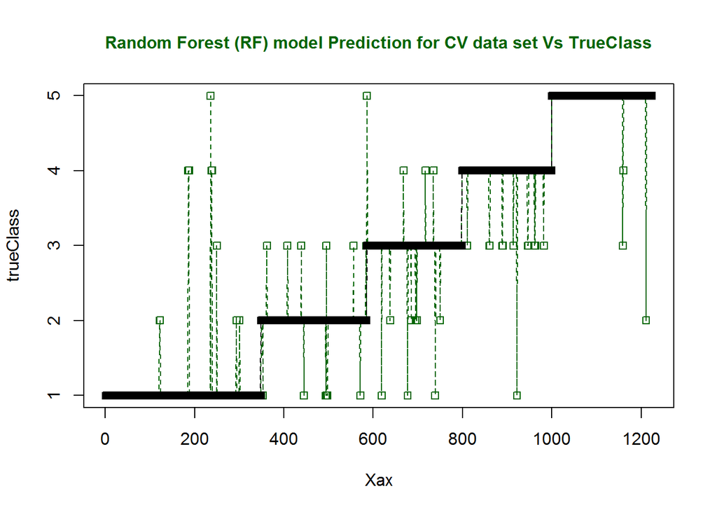

```r
plot(Xax,trueClass,col='white')
lines(predict4_rf, type="o", pch=22, lty=2, col="darkgreen")
lines(trueClass, type="o", pch=22, lty=2, col="black")
title(main="Random Forest (RF) model Prediction for CV data set Vs TrueClass",cex.main=1, col.main="darkgreen", font.main=2)
```

### Predict the 20 data set using the rainForest model#4 as it gave the maximum accuracy

```r
test_prinComponents$classe <- predict(model4,test_prinComponents[,-13])
# Results for the 20 test Cases
cbind(testData$problem_id,as.character(test_prinComponents$classe))
```

```
##       [,1] [,2]
##  [1,] "1"  "B"
##  [2,] "2"  "A"
##  [3,] "3"  "A"
##  [4,] "4"  "A"
##  [5,] "5"  "A"
##  [6,] "6"  "E"
##  [7,] "7"  "D"
##  [8,] "8"  "B"
##  [9,] "9"  "A"
## [10,] "10" "A"
## [11,] "11" "B"
## [12,] "12" "C"
## [13,] "13" "B"
## [14,] "14" "A"
## [15,] "15" "E"
## [16,] "16" "E"
## [17,] "17" "A"
## [18,] "18" "B"
## [19,] "19" "B"
## [20,] "20" "B"
```